# Projection à 20 ans sans déversement et avec hypothèses sur évolution des débits

Marion Legrand & Etienne Prévost

2023-08-25

Pour commencer à regarder la sensibilité du modèle aux hypothèses d’évolution des débits, on réalise des projections à 20 ans sous 4 scénarios d’évolution des débits différents :

- Projection à 20 ans sans influence des débits. Scénario nommé “sans_Q” : on fait tourner les projections sans prise en compte de l’influence des débits sur les 20 ans de projection. Ce scénario consiste à mettre tous les débits à 0 afin d’avoir un modèle “toute chose égale par ailleurs”.

```r
if(scenario=="sans_Q"){
    for (t in (T+1):(T+20)){
      L_Q_L_mont_P_20yr_cr[t]<-0
      L_Q_L_mont_A_20yr_cr[t]<-0
      L_Q_VB_mont_P_20yr_cr[t]<-0
      L_Q_VB_mont_A_20yr_cr[t]<-0
      L_Q_P_mont_P_20yr_cr[t]<-0
      L_Q_P_mont_A_20yr_cr[t]<-0

      L_Q_VB_deval_20yr_cr[t]<-0
      L_Q_MSL_mont_20yr_cr[t]<-0
      L_Q_MSL_deval_20yr_cr[t]<-0
    }
}
```

- Les débits restent les mêmes sur la période de projection à 20 ans. Scénario nommé “identique” : durant les 20 ans de projection les débits sont suposés être les mêmes que ceux observés durant les 20 dernières années de la période rétrospective.

```r
if(scenario=="identique"){
    #Débit montaison Lempdes sur Alagnon
    Q_L_mont_P_20yr<-rnorm(n = 20, mean = mean(bugs_Q_L_mont_P_20yr), sd = sd(bugs_Q_L_mont_P_20yr))
    #Parfois peut tirer des débits négatifs. Pour éviter erreur de caclul on force les valeurs négatives à 0.001
    Q_L_mont_P_20yr[Q_L_mont_P_20yr<0]<-0.001
    L_Q_L_mont_P_20yr<-log(Q_L_mont_P_20yr)

    Q_L_mont_A_20yr<-rnorm(n = 20, mean = mean(bugs_Q_L_mont_A_20yr), sd = sd(bugs_Q_L_mont_A_20yr))
    Q_L_mont_A_20yr[Q_L_mont_A_20yr<0]<-0.001
    L_Q_L_mont_A_20yr<-log(Q_L_mont_A_20yr)

    #Débit montaison à Vieille-Brioude (secteur Langeac-Poutès)
    Q_VB_mont_P_20yr<-rnorm(n = 20, mean = mean(bugs_Q_VB_mont_P_20yr), sd = sd(bugs_Q_VB_mont_P_20yr))
    Q_VB_mont_P_20yr[Q_VB_mont_P_20yr<0]<-0.001
    L_Q_VB_mont_P_20yr<-log(Q_VB_mont_P_20yr)

    Q_VB_mont_A_20yr<-rnorm(n = 20, mean = mean(bugs_Q_VB_mont_A_20yr), sd = sd(bugs_Q_VB_mont_A_20yr))
    Q_VB_mont_A_20yr[Q_VB_mont_A_20yr<0]<-0.001
    L_Q_VB_mont_A_20yr<-log(Q_VB_mont_A_20yr)

    #Débit montaison à Prades (secteur amont Poutès)
    Q_P_mont_P_20yr<-rnorm(n = 20, mean = mean(bugs_Q_P_mont_P_20yr), sd = sd(bugs_Q_P_mont_P_20yr))
    Q_P_mont_P_20yr[Q_P_mont_P_20yr<0]<-0.001
    L_Q_P_mont_P_20yr<-log(Q_P_mont_P_20yr)

    Q_P_mont_A_20yr<-rnorm(n = 20, mean = mean(bugs_Q_P_mont_A_20yr), sd = sd(bugs_Q_P_mont_A_20yr))
    Q_P_mont_A_20yr[Q_P_mont_A_20yr<0]<-0.001
    L_Q_P_mont_A_20yr<-log(Q_P_mont_A_20yr)

     #Influence des débits sur la survie
    Q_MSL_deval_20yr<-rnorm(n = 20, mean = mean(bugs_Q_MSL_deval_20yr), sd = sd(bugs_Q_MSL_deval_20yr))
    Q_MSL_deval_20yr[Q_MSL_deval_20yr<0]<-0.001
    L_Q_MSL_deval_20yr<-log(Q_MSL_deval_20yr)

    Q_MSL_mont_20yr<-rnorm(n = 20, mean = mean(bugs_Q_MSL_mont_20yr), sd = sd(bugs_Q_MSL_mont_20yr))
    Q_MSL_mont_20yr[Q_MSL_mont_20yr<0]<-0.001
    L_Q_MSL_mont_20yr<-log(Q_MSL_mont_20yr)

    Q_VB_deval_20yr<-rnorm(n = 20, mean = mean(bugs_Q_VB_deval_20yr), sd = sd(bugs_Q_VB_deval_20yr))
    Q_VB_deval_20yr[Q_VB_deval_20yr<0]<-0.001
    L_Q_VB_deval_20yr<-log(Q_VB_deval_20yr)

 #Attention on centre-réduit en utilisant les données historiques de bugs car on veut bien mettre toute la série (retrospective et projection) sur la même "échelle"
    for (t in (T+1):(T+20)){
      L_Q_L_mont_P_20yr_cr[t]<-(L_Q_L_mont_P_20yr[(t-T)]-mean(bugs_L_Q_L_mont_P))/sd(bugs_L_Q_L_mont_P)
      L_Q_L_mont_A_20yr_cr[t]<-(L_Q_L_mont_A_20yr[(t-T)]-mean(bugs_L_Q_L_mont_A))/sd(bugs_L_Q_L_mont_A)
      L_Q_VB_mont_P_20yr_cr[t]<-(L_Q_VB_mont_P_20yr[(t-T)]-mean(bugs_L_Q_VB_mont_P))/sd(bugs_L_Q_VB_mont_P)
      L_Q_VB_mont_A_20yr_cr[t]<-(L_Q_VB_mont_A_20yr[(t-T)]-mean(bugs_L_Q_VB_mont_A))/sd(bugs_L_Q_VB_mont_A)
      L_Q_P_mont_P_20yr_cr[t]<-(L_Q_P_mont_P_20yr[(t-T)]-mean(bugs_L_Q_P_mont_P))/sd(bugs_L_Q_P_mont_P)
      L_Q_P_mont_A_20yr_cr[t]<-(L_Q_P_mont_A_20yr[(t-T)]-mean(bugs_L_Q_P_mont_A))/sd(bugs_L_Q_P_mont_A)

      L_Q_VB_deval_20yr_cr[t]<-(L_Q_VB_deval_20yr[(t-T)]-mean(bugs_L_Q_VB_deval))/sd(bugs_L_Q_VB_deval)
      L_Q_MSL_mont_20yr_cr[t]<-(L_Q_MSL_mont_20yr[(t-T)]-mean(bugs_L_Q_MSL_mont))/sd(bugs_L_Q_MSL_mont)
      L_Q_MSL_deval_20yr_cr[t]<-(L_Q_MSL_deval_20yr[(t-T)]-mean(bugs_L_Q_MSL_deval))/sd(bugs_L_Q_MSL_deval)
    }
}
```

avec “bugs_Q_L_mont_P_20yr”/“bugs_Q_VB_mont_P_20yr”/“bugs_Q_P_mont_P_20yr”, etc. les débits utilisés dans bugs mais qu’on limite au 20 dernières années de la période rétrospective

- Les débits diminuent de 5% par rapport aux débits moyens des 20 dernières années (variance identique). Scénario nommé “diminue_5” : durant les 20 ans de projection les débits sont suposés être en diminution de 5% de ce qui était observé durant les 20 dernières années de la périodes rétrospectives.

```r
if(scenario=="diminue_5"){
  #Pour la moyenne on applique une diminution de 5% mais l'écart-type reste inchangé
    #Débit montaison Lempdes sur Alagnon
    Q_L_mont_P_20yr<-rnorm(n = 20, mean = mean(0.95*bugs_Q_L_mont_P_20yr), sd = sd(bugs_Q_L_mont_P_20yr))
    #Parfois peut tirer des débits négatifs. Pour éviter erreur de caclul on force les valeurs négatives à 0.001
    Q_L_mont_P_20yr[Q_L_mont_P_20yr<0]<-0.001
    L_Q_L_mont_P_20yr<-log(Q_L_mont_P_20yr)

    Q_L_mont_A_20yr<-rnorm(n = 20, mean = mean(0.95*bugs_Q_L_mont_A_20yr), sd = sd(bugs_Q_L_mont_A_20yr))
    Q_L_mont_A_20yr[Q_L_mont_A_20yr<0]<-0.001
    L_Q_L_mont_A_20yr<-log(Q_L_mont_A_20yr)

    #Débit montaison à Vieille-Brioude (secteur Langeac-Poutès)
    Q_VB_mont_P_20yr<-rnorm(n = 20, mean = mean(0.95*bugs_Q_VB_mont_P_20yr), sd = sd(bugs_Q_VB_mont_P_20yr))
    Q_VB_mont_P_20yr[Q_VB_mont_P_20yr<0]<-0.001
    L_Q_VB_mont_P_20yr<-log(Q_VB_mont_P_20yr)

    Q_VB_mont_A_20yr<-rnorm(n = 20, mean = mean(0.95*bugs_Q_VB_mont_A_20yr), sd = sd(bugs_Q_VB_mont_A_20yr))
    Q_VB_mont_A_20yr[Q_VB_mont_A_20yr<0]<-0.001
    L_Q_VB_mont_A_20yr<-log(Q_VB_mont_A_20yr)

    #Débit montaison à Prades (secteur amont Poutès)
    Q_P_mont_P_20yr<-rnorm(n = 20, mean = mean(0.95*bugs_Q_P_mont_P_20yr), sd = sd(bugs_Q_P_mont_P_20yr))
    Q_P_mont_P_20yr[Q_P_mont_P_20yr<0]<-0.001
    L_Q_P_mont_P_20yr<-log(Q_P_mont_P_20yr)

    Q_P_mont_A_20yr<-rnorm(n = 20, mean = mean(0.95*bugs_Q_P_mont_A_20yr), sd = sd(bugs_Q_P_mont_A_20yr))
    Q_P_mont_A_20yr[Q_P_mont_A_20yr<0]<-0.001
    L_Q_P_mont_A_20yr<-log(Q_P_mont_A_20yr)

     #Influence des débits sur la survie
    Q_MSL_deval_20yr<-rnorm(n = 20, mean = mean(0.95*bugs_Q_MSL_deval_20yr), sd = sd(bugs_Q_MSL_deval_20yr))
    Q_MSL_deval_20yr[Q_MSL_deval_20yr<0]<-0.001
    L_Q_MSL_deval_20yr<-log(Q_MSL_deval_20yr)

    Q_MSL_mont_20yr<-rnorm(n = 20, mean = mean(0.95*bugs_Q_MSL_mont_20yr), sd = sd(bugs_Q_MSL_mont_20yr))
    Q_MSL_mont_20yr[Q_MSL_mont_20yr<0]<-0.001
    L_Q_MSL_mont_20yr<-log(Q_MSL_mont_20yr)

    Q_VB_deval_20yr<-rnorm(n = 20, mean = mean(0.95*bugs_Q_VB_deval_20yr), sd = sd(bugs_Q_VB_deval_20yr))
    Q_VB_deval_20yr[Q_VB_deval_20yr<0]<-0.001
    L_Q_VB_deval_20yr<-log(Q_VB_deval_20yr)

 #Attention on centre-réduit en utilisant les données historiques de bugs car on veut bien mettre toute la série (retrospective et projection) sur la même "échelle"
      for (t in (T+1):(T+20)){
      L_Q_L_mont_P_20yr_cr[t]<-(L_Q_L_mont_P_20yr[(t-T)]-mean(bugs_L_Q_L_mont_P))/sd(bugs_L_Q_L_mont_P)
      L_Q_L_mont_A_20yr_cr[t]<-(L_Q_L_mont_A_20yr[(t-T)]-mean(bugs_L_Q_L_mont_A))/sd(bugs_L_Q_L_mont_A)
      L_Q_VB_mont_P_20yr_cr[t]<-(L_Q_VB_mont_P_20yr[(t-T)]-mean(bugs_L_Q_VB_mont_P))/sd(bugs_L_Q_VB_mont_P)
      L_Q_VB_mont_A_20yr_cr[t]<-(L_Q_VB_mont_A_20yr[(t-T)]-mean(bugs_L_Q_VB_mont_A))/sd(bugs_L_Q_VB_mont_A)
      L_Q_P_mont_P_20yr_cr[t]<-(L_Q_P_mont_P_20yr[(t-T)]-mean(bugs_L_Q_P_mont_P))/sd(bugs_L_Q_P_mont_P)
      L_Q_P_mont_A_20yr_cr[t]<-(L_Q_P_mont_A_20yr[(t-T)]-mean(bugs_L_Q_P_mont_A))/sd(bugs_L_Q_P_mont_A)

      L_Q_VB_deval_20yr_cr[t]<-(L_Q_VB_deval_20yr[(t-T)]-mean(bugs_L_Q_VB_deval))/sd(bugs_L_Q_VB_deval)
      L_Q_MSL_mont_20yr_cr[t]<-(L_Q_MSL_mont_20yr[(t-T)]-mean(bugs_L_Q_MSL_mont))/sd(bugs_L_Q_MSL_mont)
      L_Q_MSL_deval_20yr_cr[t]<-(L_Q_MSL_deval_20yr[(t-T)]-mean(bugs_L_Q_MSL_deval))/sd(bugs_L_Q_MSL_deval)
    }
}
```

avec “bugs_Q_L_mont_P_20yr”/“bugs_Q_VB_mont_P_20yr”/“bugs_Q_P_mont_P_20yr”, etc. les débits utilisés dans bugs mais qu’on limite au 20 dernières années de la période rétrospective

- Les débits diminuent de 10% par rapport aux débits moyens des 20 dernières années (variance identique). Scénario nommé “diminue_10” : durant les 20 ans de projection les débits sont suposés être en diminution de 10% de ce qui était observé durant les 20 dernières années de la périodes rétrospectives.

```r
if(scenario=="diminue_10"){
    #Pour la moyenne on applique une diminution de 10% mais l'écart-type reste inchangé
  #Débit montaison Lempdes sur Alagnon
    Q_L_mont_P_20yr<-rnorm(n = 20, mean = mean(0.90*bugs_Q_L_mont_P_20yr), sd = sd(bugs_Q_L_mont_P_20yr))
    #Parfois peut tirer des débits négatifs. Pour éviter erreur de caclul on force les valeurs négatives à 0.001
    Q_L_mont_P_20yr[Q_L_mont_P_20yr<0]<-0.001
    L_Q_L_mont_P_20yr<-log(Q_L_mont_P_20yr)

    Q_L_mont_A_20yr<-rnorm(n = 20, mean = mean(0.90*bugs_Q_L_mont_A_20yr), sd = sd(bugs_Q_L_mont_A_20yr))
    Q_L_mont_A_20yr[Q_L_mont_A_20yr<0]<-0.001
    L_Q_L_mont_A_20yr<-log(Q_L_mont_A_20yr)

    #Débit montaison à Vieille-Brioude (secteur Langeac-Poutès)
    Q_VB_mont_P_20yr<-rnorm(n = 20, mean = mean(0.90*bugs_Q_VB_mont_P_20yr), sd = sd(bugs_Q_VB_mont_P_20yr))
    Q_VB_mont_P_20yr[Q_VB_mont_P_20yr<0]<-0.001
    L_Q_VB_mont_P_20yr<-log(Q_VB_mont_P_20yr)

    Q_VB_mont_A_20yr<-rnorm(n = 20, mean = mean(0.90*bugs_Q_VB_mont_A_20yr), sd = sd(bugs_Q_VB_mont_A_20yr))
    Q_VB_mont_A_20yr[Q_VB_mont_A_20yr<0]<-0.001
    L_Q_VB_mont_A_20yr<-log(Q_VB_mont_A_20yr)

    #Débit montaison à Prades (secteur amont Poutès)
    Q_P_mont_P_20yr<-rnorm(n = 20, mean = mean(0.90*bugs_Q_P_mont_P_20yr), sd = sd(bugs_Q_P_mont_P_20yr))
    Q_P_mont_P_20yr[Q_P_mont_P_20yr<0]<-0.001
    L_Q_P_mont_P_20yr<-log(Q_P_mont_P_20yr)

    Q_P_mont_A_20yr<-rnorm(n = 20, mean = mean(0.90*bugs_Q_P_mont_A_20yr), sd = sd(bugs_Q_P_mont_A_20yr))
    Q_P_mont_A_20yr[Q_P_mont_A_20yr<0]<-0.001
    L_Q_P_mont_A_20yr<-log(Q_P_mont_A_20yr)

     #Influence des débits sur la survie
    Q_MSL_deval_20yr<-rnorm(n = 20, mean = mean(0.90*bugs_Q_MSL_deval_20yr), sd = sd(bugs_Q_MSL_deval_20yr))
    Q_MSL_deval_20yr[Q_MSL_deval_20yr<0]<-0.001
    L_Q_MSL_deval_20yr<-log(Q_MSL_deval_20yr)

    Q_MSL_mont_20yr<-rnorm(n = 20, mean = mean(0.90*bugs_Q_MSL_mont_20yr), sd = sd(bugs_Q_MSL_mont_20yr))
    Q_MSL_mont_20yr[Q_MSL_mont_20yr<0]<-0.001
    L_Q_MSL_mont_20yr<-log(Q_MSL_mont_20yr)

    Q_VB_deval_20yr<-rnorm(n = 20, mean = mean(0.90*bugs_Q_VB_deval_20yr), sd = sd(bugs_Q_VB_deval_20yr))
    Q_VB_deval_20yr[Q_VB_deval_20yr<0]<-0.001
    L_Q_VB_deval_20yr<-log(Q_VB_deval_20yr)

 #Attention on centre-réduit en utilisant les données historiques de bugs car on veut bien mettre toute la série (retrospective et projection) sur la même "échelle"
      for (t in (T+1):(T+20)){
      L_Q_L_mont_P_20yr_cr[t]<-(L_Q_L_mont_P_20yr[(t-T)]-mean(bugs_L_Q_L_mont_P))/sd(bugs_L_Q_L_mont_P)
      L_Q_L_mont_A_20yr_cr[t]<-(L_Q_L_mont_A_20yr[(t-T)]-mean(bugs_L_Q_L_mont_A))/sd(bugs_L_Q_L_mont_A)
      L_Q_VB_mont_P_20yr_cr[t]<-(L_Q_VB_mont_P_20yr[(t-T)]-mean(bugs_L_Q_VB_mont_P))/sd(bugs_L_Q_VB_mont_P)
      L_Q_VB_mont_A_20yr_cr[t]<-(L_Q_VB_mont_A_20yr[(t-T)]-mean(bugs_L_Q_VB_mont_A))/sd(bugs_L_Q_VB_mont_A)
      L_Q_P_mont_P_20yr_cr[t]<-(L_Q_P_mont_P_20yr[(t-T)]-mean(bugs_L_Q_P_mont_P))/sd(bugs_L_Q_P_mont_P)
      L_Q_P_mont_A_20yr_cr[t]<-(L_Q_P_mont_A_20yr[(t-T)]-mean(bugs_L_Q_P_mont_A))/sd(bugs_L_Q_P_mont_A)

      L_Q_VB_deval_20yr_cr[t]<-(L_Q_VB_deval_20yr[(t-T)]-mean(bugs_L_Q_VB_deval))/sd(bugs_L_Q_VB_deval)
      L_Q_MSL_mont_20yr_cr[t]<-(L_Q_MSL_mont_20yr[(t-T)]-mean(bugs_L_Q_MSL_mont))/sd(bugs_L_Q_MSL_mont)
      L_Q_MSL_deval_20yr_cr[t]<-(L_Q_MSL_deval_20yr[(t-T)]-mean(bugs_L_Q_MSL_deval))/sd(bugs_L_Q_MSL_deval)
    }
}
```

avec “bugs_Q_L_mont_P_20yr”/“bugs_Q_VB_mont_P_20yr”/“bugs_Q_P_mont_P_20yr”, etc. les débits utilisés dans bugs mais qu’on limite au 20 dernières années de la période rétrospective

## Scénario de débit “sans_Q”

Afin de comparer les résultats, on réalise les projections à 20 ans pour deux types de modèle : celui incluant un modèle de mélange sur les effectifs de retour à Vichy et celui n’incluant pas ce modèle de mélange.

### Projection à 20 ans pour le modèle incluant la distribution de mélange à Vichy

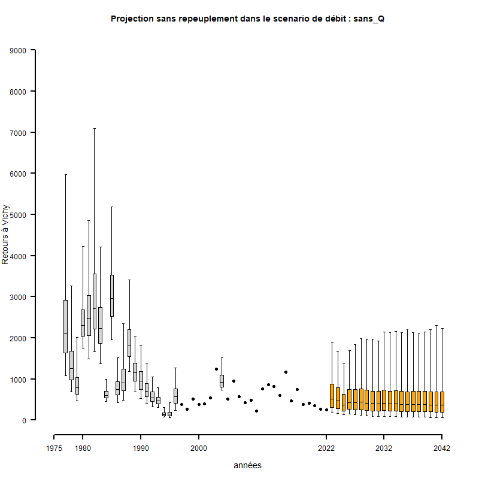

Projection à 20 ans sans repeuplement sous l’hypothèse de débits nuls

Dans ce scénario sans prise en compte de l’influence des débits sur les 20 ans de projection (débit à 0), la moyenne des adultes de retour à Vichy durant les 5 dernières années de la période de projection est de :

```
## [1] 572
```

### Projection à 20 ans pour le modèle n’incluant pas de distribution de mélange à Vichy

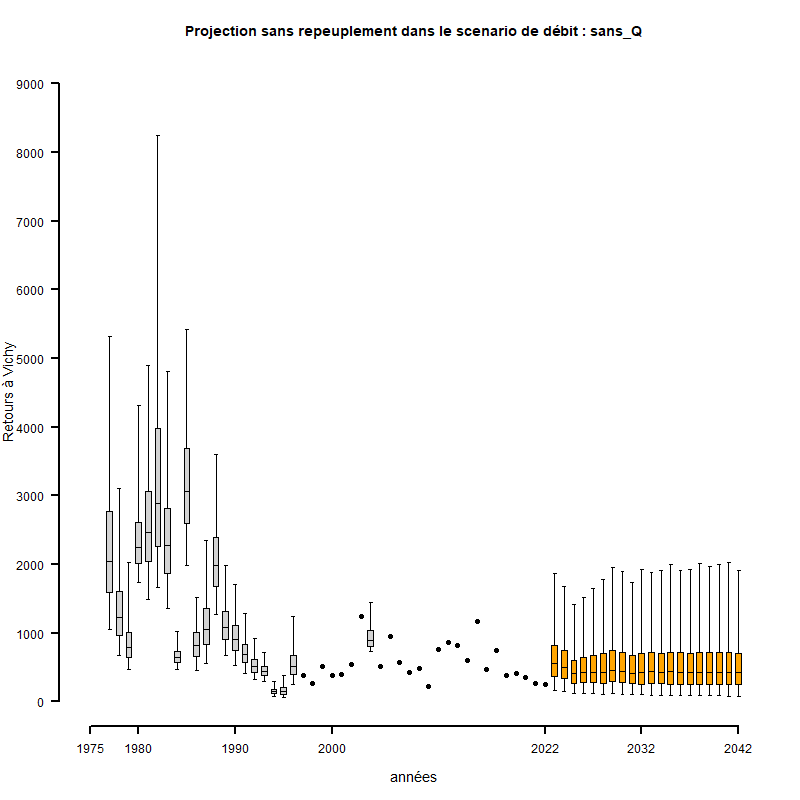

Projection à 20 ans sans repeuplement sous l’hypothèse de débits nuls - Modèle sans distribution de mélange à Vichy

Dans ce scénario sans prise en compte de l’influence des débits sur les 20 ans de projection (débit à 0), la moyenne des adultes de retour à Vichy durant les 5 dernières années de la période de projection est de :

```
## [1] 576
```

## Scénario de débit “identique”

### Projection à 20 ans pour le modèle incluant la distribution de mélange à Vichy

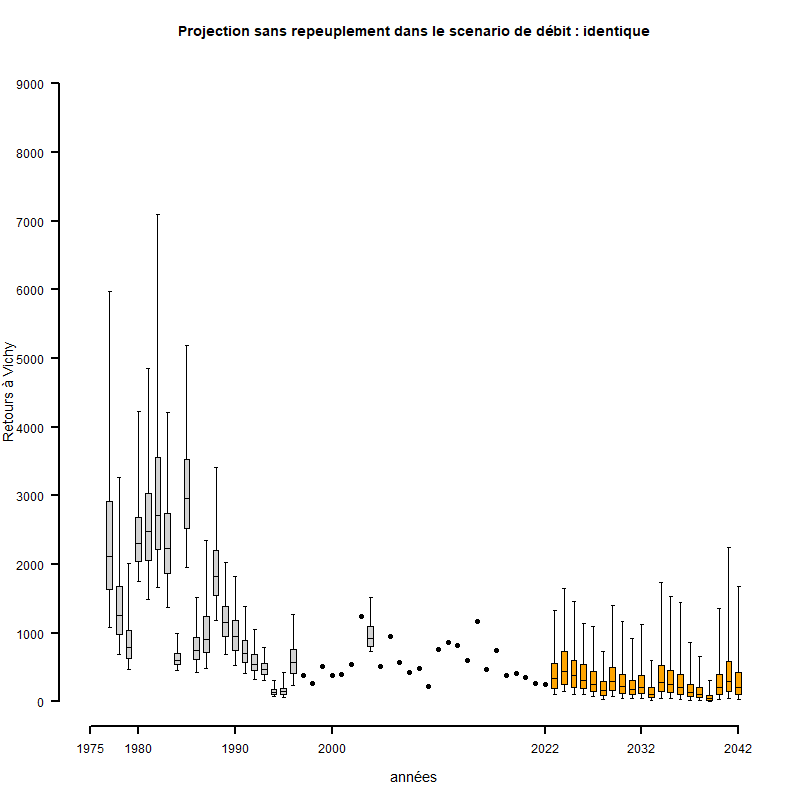

Projection à 20 ans sans repeuplement sous l’hypothèse de débits identiques à ceux observés durant les 20 dernières années de la période rétrospective

Dans ce scénario de débits identiques à ce qui a été observé durant les 20 dernières années de la période rétrospective, la moyenne des adultes de retour à Vichy durant les 5 dernières années de la période de projection est de :

```
## [1] 294
```

### Projection à 20 ans pour le modèle n’incluant pas de distribution de mélange à Vichy

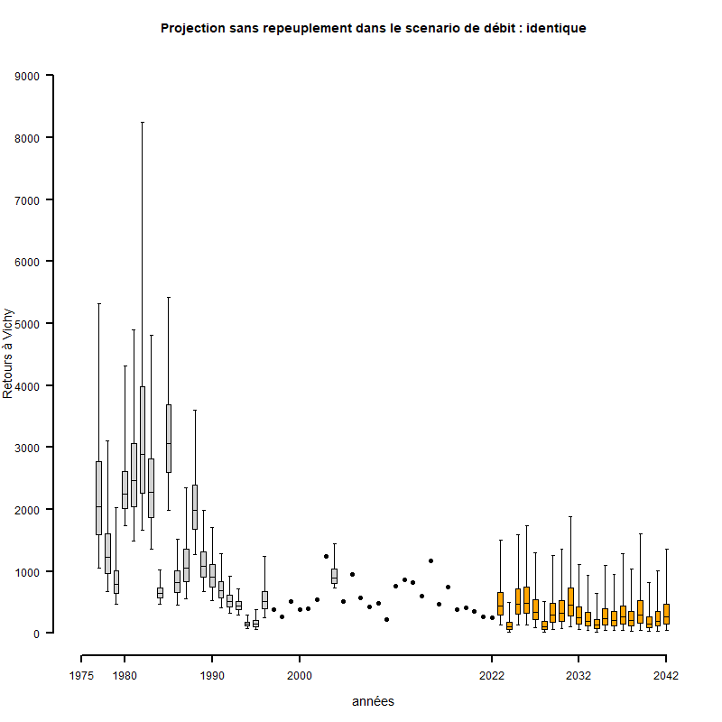

Projection à 20 ans sans repeuplement sous l’hypothèse de débits identiques à ceux observés durant les 20 dernières années de la période rétrospective - Modèle sans distribution de mélange à Vichy

Dans ce scénario de débits identiques à ce qui a été observé durant les 20 dernières années de la période rétrospective, la moyenne des adultes de retour à Vichy durant les 5 dernières années de la période de projection est de :

```
## [1] 321
```

## Scénario de débit “diminue_5”

### Projection à 20 ans pour le modèle incluant la distribution de mélange à Vichy

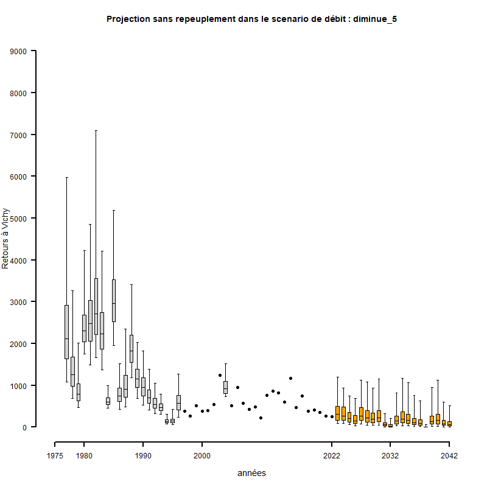

Projection à 20 ans sans repeuplement sous l’hypothèse de débits en diminution de 5% par rapport à ceux observés durant les 20 dernières années de la période rétrospective

Dans ce scénario de débits en diminution de 5% par rapport aux débits observés durant les 20 dernières années de la période rétrospective, la moyenne des adultes de retour à Vichy durant les 5 dernières années de la période de projection est de :

```
## [1] 154
```

### Projection à 20 ans pour le modèle n’incluant pas de distribution de mélange à Vichy

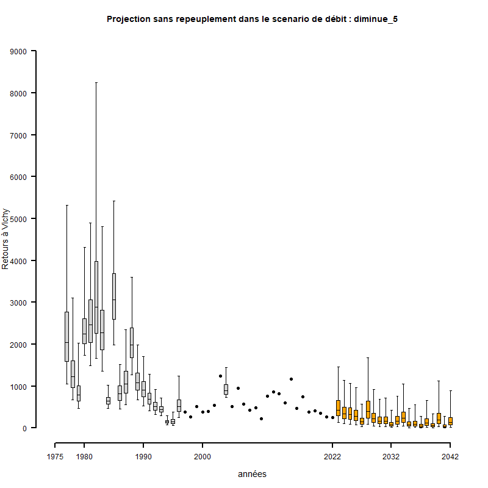

Projection à 20 ans sans repeuplement sous l’hypothèse de débits en diminution de 5% par rapport à ceux observés durant les 20 dernières années de la période rétrospective - Modèle sans distribution de mélange à Vichy

Dans ce scénario de débits en diminution de 5% par rapport aux débits observés durant les 20 dernières années de la période rétrospective, la moyenne des adultes de retour à Vichy durant les 5 dernières années de la période de projection est de :

```
## [1] 168
```

## Scénario de débit “diminue_10”

### Projection à 20 ans pour le modèle incluant la distribution de mélange à Vichy

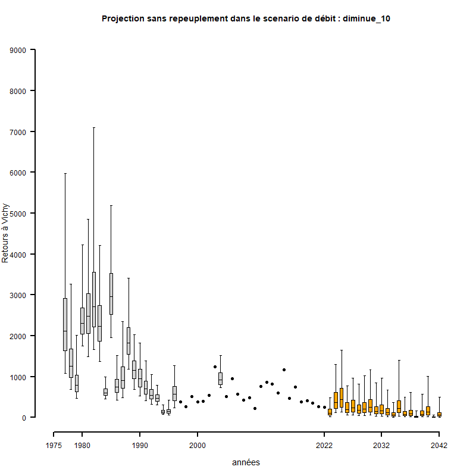

Projection à 20 ans sans repeuplement sous l’hypothèse de débits en diminution de 10% par rapport à ceux observés durant les 20 dernières années de la période rétrospective

Dans ce scénario de débits en diminution de 10% par rapport aux débits observés durant les 20 dernières années de la période rétrospective, la moyenne des adultes de retour à Vichy durant les 5 dernières années de la période de projection est de :

```
## [1] 105
```

### Projection à 20 ans pour le modèle n’incluant pas de distribution de mélange à Vichy

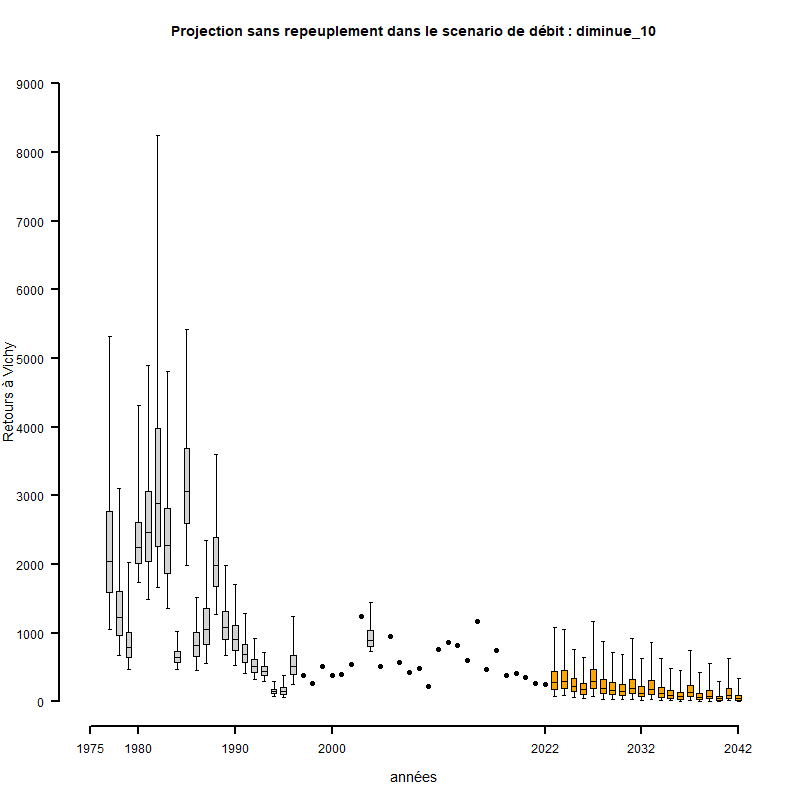

Projection à 20 ans sans repeuplement sous l’hypothèse de débits en diminution de 10% par rapport à ceux observés durant les 20 dernières années de la période rétrospective - Modèle sans distribution de mélange à Vichy

Dans ce scénario de débits en diminution de 10% par rapport aux débits observés durant les 20 dernières années de la période rétrospective, la moyenne des adultes de retour à Vichy durant les 5 dernières années de la période de projection est de :

```
## [1] 108
```